# Get EPCHC Data, Tidy it Up & Perform TBEP Annual WQ Assessment

Ed Sherwood esherwood@epchc.org

February 4, 2019

## Long-Term Water Quality Monitoring Dataset (1972-Present) Background

The Environmental Protection Commission of Hillsborough County (EPCHC) has been monitoring water quality in Tampa Bay for over 40 years. The EPCHC published a Surface Water Quality Monitoring Report in November 2014 which further describes the monitoring program and the parameters assessed in Tampa Bay and its tributaries. You can view the report under the “Publications” link on EPCHC’s main webpage here: http://www.epchc.org/. For more details about particular monitoring stations see: http://http://www.epchc.org/index.aspx?NID=219. The water quality monitoring data collected by the EPCHC has been the foundation for the Tampa Bay Estuary Program’s annual water quality assessments (see http://tbeptech.org/TBEP_TECH_PUBS/2017/TBEP_01_17_2016_Decision_Matrix_Results_Update.pdf). The following code will fully reproduce the water quality assessments for each major bay segment of Tampa Bay.

## Code to Download EPCHC Dataset

```r
#URL of EPCHC's long-term dataset in Excel Spreadsheet format
 epchc_url <- "ftp://ftp.epchc.org/EPC_ERM_FTP/WQM_Reports/RWMDataSpreadsheet_ThroughCurrentReportMonth.xlsx"
#Download data from EPCHC's ftp site
 download.file(url = epchc_url, destfile = './data-raw/epchc.xlsx', method = "libcurl", mode = "wb")
```

## Correctly Import EPCHC xlsx Data File into R

The following code will import the full EPCHC dataset with formatted columns correctly into R, and then assign the columns standardized names (this can be changed in the “./data-raw/epchc_column_names.csv” file.

```r
#EPC data column name file
epcnames <- readLines("./data-raw/epchc_column_names.csv")

#EPC sites within Tampa Bay used for the Annual TBEP WQ Assessment
epcsites <- c(6, 7, 8, 44, 52, 55, 70, 71, 73, 80, 36, 38, 40, 41, 46, 47, 50, 51, 60, 63, 64, 65, 66, 67, 68, 9,               11, 81, 84, 13, 14, 32, 33, 16, 19, 28, 82, 23, 24, 25, 90, 91, 92, 93, 95)
#Station Lists by Bay Segment
otb_stations <- c(36, 38, 40, 41, 46, 47, 50, 51, 60, 63, 64, 65, 66, 67, 68)
hb_stations <- c(6, 7, 8, 44, 52, 55, 70, 71, 73, 80)
mtb_stations <- c(9, 11, 81, 84, 13, 14, 32, 33, 16, 19, 28, 82)
ltb_stations <- c(23, 24, 25, 90, 91, 92, 93, 95)
#Short Bay Segment Names
bay_segments = c("OTB", "HB", "MTB", "LTB")

#Data frame that lists bay segment specific management targets + low and high magnitude exceedance thresholds
targets <- data.frame(bay_segment = c("OTB", "HB", "MTB", "LTB"),
                           name = c("Old Tampa Bay", "Hillsborough Bay", "Middle Tampa Bay", "Lower Tampa Bay"),
                           chla_target = c(8.5, 13.2, 7.4, 4.6),
                           chla_smallex = c(8.9, 14.1, 7.9, 4.8),
                           chla_thresh = c(9.3, 15.0, 8.5, 5.1),
                           la_target = c(0.83, 1.58, 0.83, 0.63),
                           la_smallex = c(0.86, 1.63, 0.87, 0.66),
                           la_thresh = c(0.88, 1.67, 0.91, 0.68))

#Import the raw dataset into R
epcdata <- read_xlsx("./data-raw/epchc.xlsx",
                     sheet="RWMDataSpreadsheet",
                     col_types = c("numeric", "numeric", "text", "text", "text", "text",
                                   "numeric", "numeric", "text", "numeric", "numeric",
                                   "text", "date", "text", "numeric", "text", "text",
                                   "numeric", "numeric", "numeric", "numeric", "text",
                                   "text", "text", "numeric", "text", "numeric", "text",
                                   "numeric", "text", "numeric", "text", "numeric",
                                   "text", "numeric", "text", "numeric", "text",
                                   "numeric", "text", "numeric", "text", "numeric",
                                   "text", "numeric", "text", "numeric", "text",
                                   "numeric", "text", "numeric", "text", "numeric",
                                   "text", "numeric", "text", "numeric", "text",
                                   "numeric", "text", "numeric", "text", "numeric",
                                   "text", "numeric", "text", "text", "text", "text",
                                   "text", "text", "text", "text", "text", "text",
                                   "text", "text", "text", "text", "text", "text",
                                   "text", "text", "text", "text", "text", "text",
                                   "text", "text", "text", "text", "text", "text",
                                   "text", "text", "text", "text", "text", "text",
                                   "text", "text", "text", "text", "text", "text",
                                   "text", "text", "text", "text", "text", "text",
                                   "text", "text", "text", "text", "text", "text",
                                   "text", "text", "text", "text", "text", "text",
                                   "text", "text", "text", "text", "text", "text",
                                   "text", "text", "text", "text", "text", "text",
                                   "text", "text", "text", "text", "text", "text",
                                   "text", "text", "text", "text", "text", "text",
                                   "text", "text", "text", "text", "text", "text",
                                   "text", "text", "text", "text", "text", "text",
                                   "text", "text", "text"),
                     col_names = epcnames,
                     skip=1, na="")
save(epcdata, file = './data-raw/epcdata.RData', compress = 'xz')
#load('./data-raw/epcdata.Rdata')
```

## Run Some Crude Checks on the Data

Filter entire EPCHC dataset and plot standard sites used in TBEP bay segment analyses.

```r
#Filter entire EPCHC dataset
wqdata <- epcdata %>%
          select(StationNumber,
                 Latitude,
                 Longitude,
                 SampleTime,
                 Total_Depth_m,
                 Sample_Depth_m,
                 Secchi_Depth_m,
                 Secchi_Q,
                 Chlorophyll_a_uncorr_ugL,
                 Chlorophyll_a_uncorr_Q) %>%
          mutate(epchc_station = as.numeric(StationNumber),
                 sd_m = as.numeric(Secchi_Depth_m),
                 sd_check = as.numeric((Total_Depth_m*3.2809)-(Secchi_Depth_m*3.2809)),
                 chla = as.numeric(Chlorophyll_a_uncorr_ugL),
                 yr = year(SampleTime),
                 mo = month(SampleTime)) %>%
          filter(epchc_station %in% epcsites)
```

```r
#Assign NAs to VOB secchi disk depths or secchis <0.5ft from bottom -- Janicki protocols
wqdata <- within(wqdata, sd_m[Secchi_Q == ">"] <- NA)
wqdata <- within(wqdata, sd_m[sd_check < 0.5] <- NA)

wqdata$bay_segment <- ifelse(wqdata$epchc_station %in% hb_stations, "HB",
                             ifelse(wqdata$epchc_station %in% otb_stations, "OTB",
                                    ifelse(wqdata$epchc_station %in% mtb_stations, "MTB",
                                           ifelse(wqdata$epchc_station %in% ltb_stations, "LTB",NA))))


#Display station locations
wqsites <- wqdata %>%
           select(epchc_station, Latitude, Longitude) %>%
           unique()

map <- leaflet(wqsites) %>%
              addProviderTiles(providers$CartoDB.Positron) %>%
              addCircleMarkers(~Longitude, ~Latitude,
                               radius = 6,
                               color = 'black',
                               stroke = FALSE,
                               opacity = 0.8,
                               popup = ~as.character(paste('EPC Station:', epchc_station)),
                               group = 'Water quality') %>%
              addLayersControl(overlayGroups = c('Water quality'),
                               options = layersControlOptions(collapsed = FALSE))
map
```

[interactive chart not shown]

```r
#Generate annual averages for each bay segment
tbdata <-subset(wqdata, bay_segment != "MTB")
tbmonchla <- tbdata %>%
               select(yr, mo, bay_segment, chla) %>%
               drop_na() %>%
               group_by(yr, mo, bay_segment) %>%
               summarise(mean_chla = mean(chla))
tbyrchla <- tbmonchla %>%
               select(bay_segment, yr, mean_chla) %>%
               drop_na() %>%
               group_by(bay_segment, yr) %>%
               summarise(mean_chla = mean(mean_chla))
tbmonsdm <- tbdata %>%
               select(yr, mo, bay_segment, sd_m) %>%
               drop_na() %>%
               group_by(yr, mo, bay_segment) %>%
               summarise(mean_sdm = mean(sd_m))

tbyrsdm <- tbmonsdm %>%
               select(bay_segment, yr, mean_sdm) %>%
               drop_na() %>%
               group_by(bay_segment, yr) %>%
               summarise(mean_sdm = mean(mean_sdm))
#Process MTB data using weighted averages of 3 subsegments
mtbdata <- subset(wqdata, bay_segment == "MTB")
mtbdata$baysegment <- ifelse(mtbdata$epchc_station %in% c(9, 11, 81, 84), "MT1",
                             ifelse(mtbdata$epchc_station %in% c(13, 14, 32, 33), "MT2",
                                    ifelse(mtbdata$epchc_station %in% c(16, 19, 28, 82), "MT3", NA)))
mtbmonthlychla <- mtbdata %>%
                select(yr, mo, baysegment, chla) %>%
                drop_na() %>%
                group_by(yr, mo, baysegment) %>%
                summarise(mean_chla = mean(chla))
mtbmonchla <- mtbmonthlychla

mtbmonthlysdm <- mtbdata %>%
                select(yr, mo, baysegment, sd_m) %>%
                drop_na() %>%
                group_by(yr, mo, baysegment) %>%
                summarise(mean_sd_m = mean(sd_m))
mtbmonsdm <- mtbmonthlysdm

mtbmonchla$chla <- ifelse(mtbmonchla$baysegment=="MT1", mtbmonchla$mean_chla*2108.7,
                        ifelse(mtbmonchla$baysegment=="MT2", mtbmonchla$mean_chla*1041.9,
                               ifelse(mtbmonchla$baysegment=="MT3", mtbmonchla$mean_chla*974.6, NA)))
mtbmonsdm$sdm <- ifelse(mtbmonsdm$baysegment=="MT1", mtbmonsdm$mean_sd_m*2108.7,
                        ifelse(mtbmonsdm$baysegment=="MT2", mtbmonsdm$mean_sd_m*1041.9,
                               ifelse(mtbmonsdm$baysegment=="MT3", mtbmonsdm$mean_sd_m*974.6, NA)))
mtbmoyrchla <- mtbmonchla %>%
                select(yr, mo, baysegment, chla) %>%
                drop_na() %>%
                group_by(yr, mo) %>%
                summarise(sum_chla = sum(chla)) %>%
                mutate(mean_chla = sum_chla/4125.2,
                       bay_segment ="MTB")

mtbyrchla <- mtbmoyrchla %>%
                select(yr, mean_chla) %>%
                drop_na() %>%
                group_by(yr) %>%
                summarise(mean_chla = mean(mean_chla)) %>%
                mutate(bay_segment = "MTB")


mtbmoyrsdm <- mtbmonsdm %>%
                select(yr, mo, baysegment, sdm) %>%
                drop_na() %>%
                group_by(yr, mo) %>%
                summarise(sum_sdm = sum(sdm)) %>%
                mutate(mean_sdm = sum_sdm/4125.2,
                       bay_segment ="MTB")

mtbyrsdm <- mtbmoyrsdm %>%
                select(yr, mean_sdm) %>%
                drop_na() %>%
                group_by(yr) %>%
                summarise(mean_sdm = mean(mean_sdm)) %>%
                mutate(bay_segment = "MTB")

#Put it all together
chladata <- bind_rows(tbyrchla, mtbyrchla)
chlamodata <- bind_rows(tbmonchla, mtbmoyrchla)
sdmdata <- bind_rows(tbyrsdm, mtbyrsdm)
sdmmodata <- bind_rows(tbmonsdm, mtbmoyrsdm)

sdmdata$mean_la <- ifelse(sdmdata$bay_segment =="OTB", 1.49/sdmdata$mean_sdm,
                             ifelse(sdmdata$bay_segment =="HB", 1.61/sdmdata$mean_sdm,
                                    ifelse(sdmdata$bay_segment =="MTB", 1.49/sdmdata$mean_sdm,
                                           ifelse(sdmdata$bay_segment =="LTB", 1.84/sdmdata$mean_sdm,NA))))
```

## Plot Mean Annual Chl-a Values by Bay Segment

```r
cols <- c("Annual Mean"="red", "Management Target"="blue", "Regulatory Threshold"="blue", "Small Mag. Exceedance"="blue", "Large Mag. Exceedance"="blue")
for (i in seq_along(bay_segments)) {
   chlaplot <- chladata %>%
                 filter(bay_segment == bay_segments[i] & yr<2019) %>%
                 ggplot(aes(x=yr)) +
                   geom_point(aes(y=mean_chla, colour="Annual Mean"), size=3) +
                   geom_line(aes(y=mean_chla, colour="Annual Mean"), size=0.75) +
                   geom_hline(data=targets, aes(yintercept = as.numeric(chla_thresh[i]),
                                                colour="Regulatory Threshold")) +
                   ggtitle(paste(targets$name[i])) +
                   geom_text(data=targets, parse = TRUE,
                             aes(1973, as.numeric(chla_thresh[i]),
                                 label = paste(chla_thresh[i],"~ mu * g%.%L^{-1}"),
                                 hjust = 0.2, vjust = -0.3)) +
                   ylab(expression("Mean Annual Chlorophyll-a ("~ mu * "g\u00B7L"^-1 *")")) +
                   xlab("") +
                   scale_x_continuous(breaks=seq(1973,2019,by=1),
                                      labels=c(1973, rep("",3), 1977, rep("",3), 1981, rep("",3),
                                               1985, rep("",3), 1989, rep("",3), 1993, rep("",3),
                                               1997, rep("",3), 2001, rep("",3), 2005, rep("",3),
                                               2009, rep("",3), 2013, rep("",3), 2017, rep("",2)),
                                      expand = c(0.035,0)) +
                   theme(plot.title = element_text(hjust = 0.5),
                         panel.grid.minor=element_blank(),
                         panel.grid.major=element_blank(),
                         legend.position = c(0.88, 0.95),
                         legend.background = element_rect(fill=NA)) +
                   scale_colour_manual(name="", values = cols,
                                       labels=c("Annual Mean", "Regulatory Threshold"))
   cat("###", paste(targets$name[i]), "\n")
   print(chlaplot)
   cat("\n\n")
}
```

### Old Tampa Bay

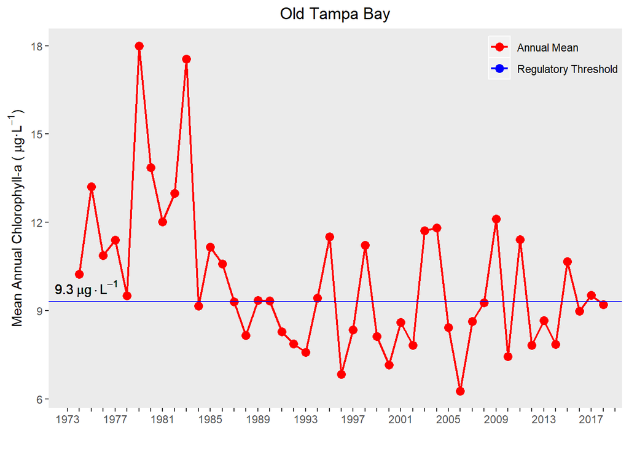

### Hillsborough Bay

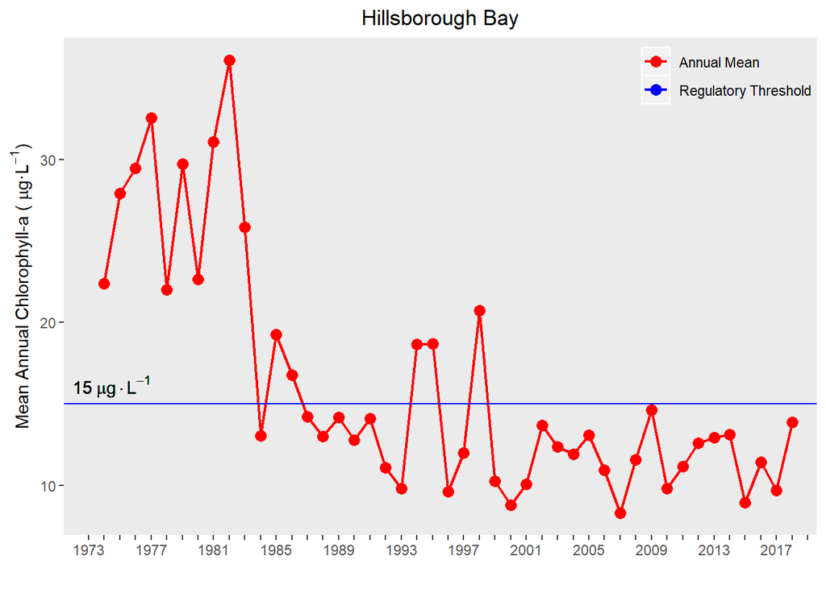

### Middle Tampa Bay

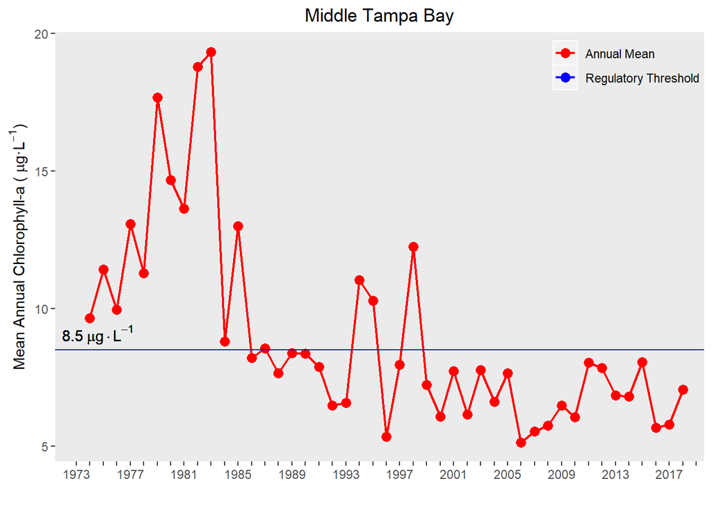

### Lower Tampa Bay

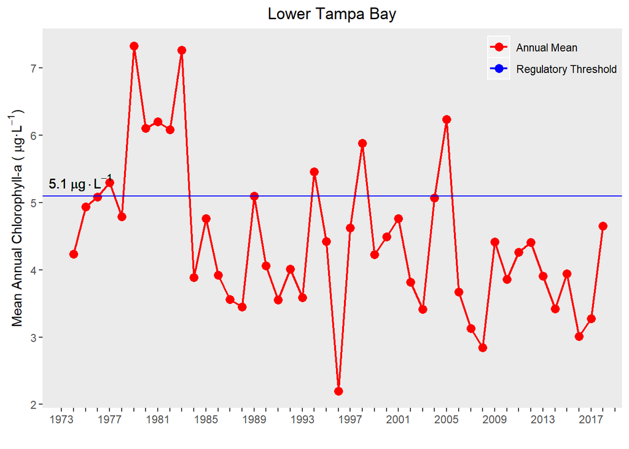

## Plot Mean Annual Light Attenuation Values by Bay Segment

```r
for (i in seq_along(bay_segments)) {
    sdmplot <- sdmdata %>%
                 filter(bay_segment == bay_segments[i] & yr<2019) %>%
                 ggplot(aes(x=yr)) +
                   geom_point(aes(y=mean_la, colour="Annual Mean"), size=3) +
                   geom_line(aes(y=mean_la, colour="Annual Mean"), size=0.75) +
                   geom_hline(data=targets, aes(yintercept = as.numeric(la_target[i]),
                                                colour="Management Target")) +
                   ggtitle(paste(targets$name[i])) +
                   geom_text(data=targets, parse = T,
                             aes(1973, as.numeric(la_target[i]),
                                 label = paste(la_target[i],"~m","^{-1}"),
                                 hjust = 0.3, vjust = -0.3)) +
                   ylab(expression("Mean Annual Light Attenuation (m  " ^-1 *")")) +
                   xlab("") +
                   scale_x_continuous(breaks=seq(1973,2019,by=1),
                                      labels=c(1973, rep("",3), 1977, rep("",3), 1981, rep("",3),
                                               1985, rep("",3), 1989, rep("",3), 1993, rep("",3),
                                               1997, rep("",3), 2001, rep("",3), 2005, rep("",3),
                                               2009, rep("",3), 2013, rep("",3), 2017, rep("",2)),
                                      expand = c(0.035,0)) +
                   theme(plot.title = element_text(hjust = 0.5),
                         panel.grid.minor=element_blank(),
                         panel.grid.major=element_blank(),
                         legend.position = c(0.88, 0.95),
                         legend.background = element_rect(fill=NA)) +
                   scale_colour_manual(name="", values = cols,
                                       labels=c("Annual Mean", "Management Target"))
   cat("###", paste(targets$name[i]), "\n")
   print(sdmplot)
   cat("\n\n")
}
```

### Old Tampa Bay

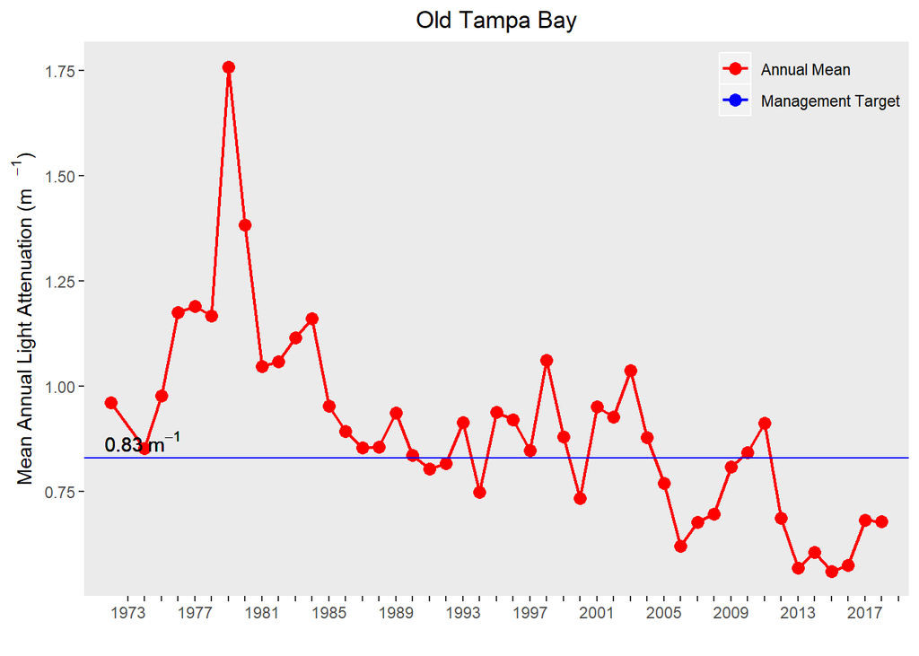

### Hillsborough Bay

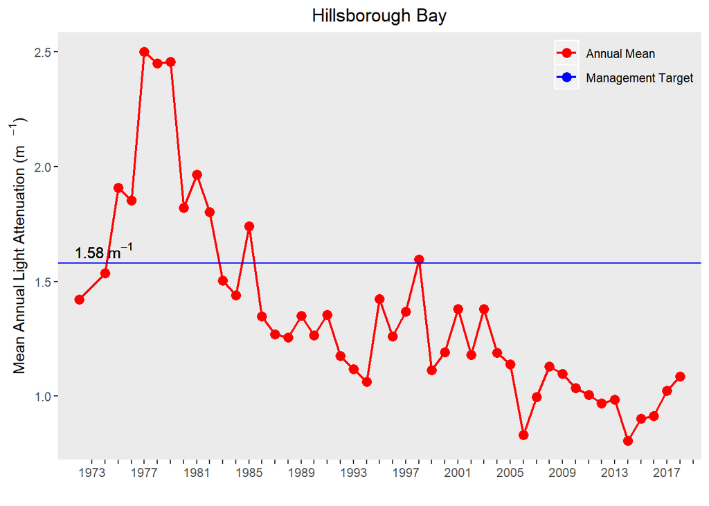

### Middle Tampa Bay

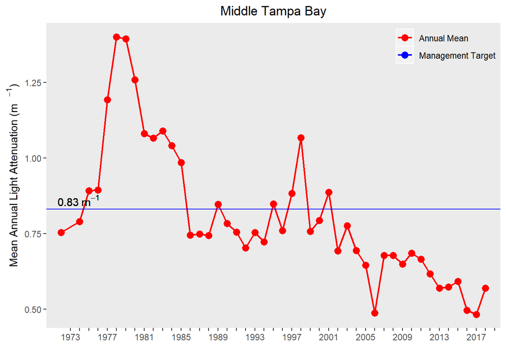

### Lower Tampa Bay

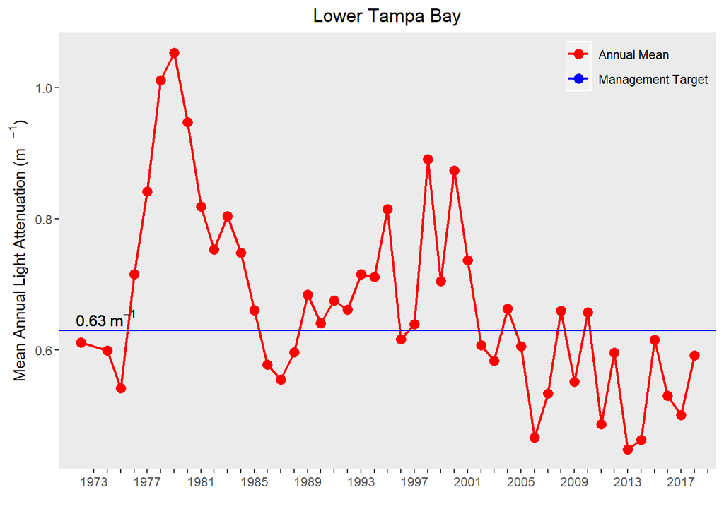

## Export Annual Values as a Tidy CSV File

Export final datasets to csv files in ‘data-processed’ folder.

```r
write.csv(chladata, file = "./data-processed/TB_Chla_Annual_Means.csv")
write.csv(chlamodata, file = "./data-processed/TB_Chla_Monthly_means.csv")
write.csv(sdmdata, file = "./data-processed/TB_Secchi_Annual_Means.csv")
write.csv(sdmmodata, file = "./data-processed/TB_Secchi_Monthly_means.csv")
```